# Mortalidad por cáncer de pulmón en Ohio (décadas de 1960 a 1980)

### *Independecia*

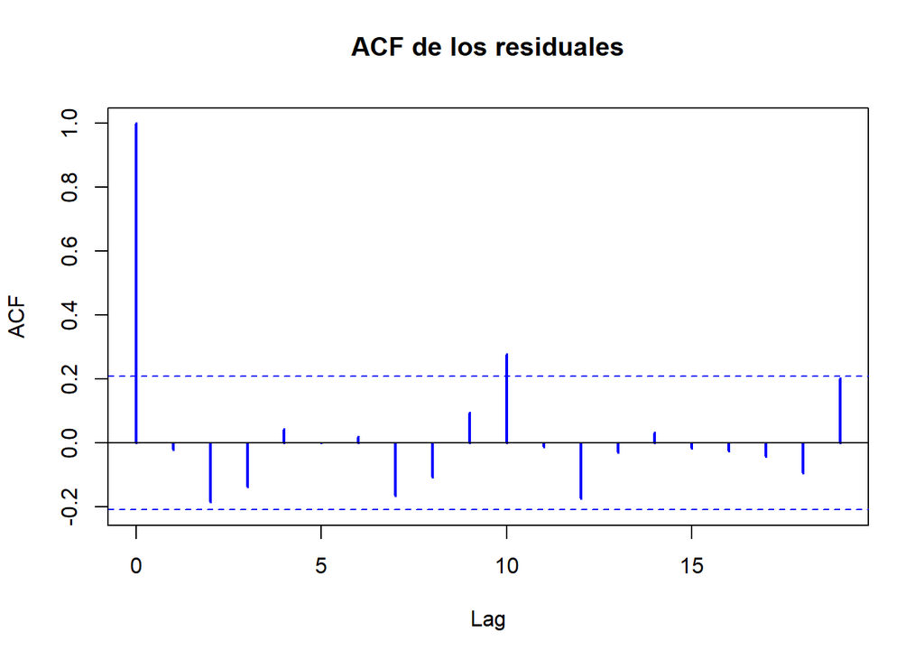

```r
acf(residuals.glm(bn_final), main = "ACF de los residuales", col = "blue", lwd = 2)
```

El correlograma muestra que no parece haber una correlación fuerte en los residuales, sin embargo, se decidió hacer una verificación más formal del supuesto de independencia en los errores, usando la prueba de Durbin Watson

```r
dwtest(bn_final)
```

```
##
##  Durbin-Watson test
##
## data:  bn_final
## DW = 2.2053, p-value = 0.8269
## alternative hypothesis: true autocorrelation is greater than 0
```

### *Normalidad*

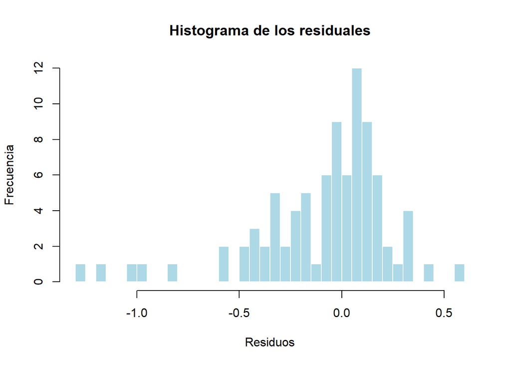

```r
hist(residuals.glm(bn_final),breaks = 50, main = "Histograma de los residuales", xlab = "Residuos", ylab = "Frecuencia", col = "lightblue", border = "white")
```

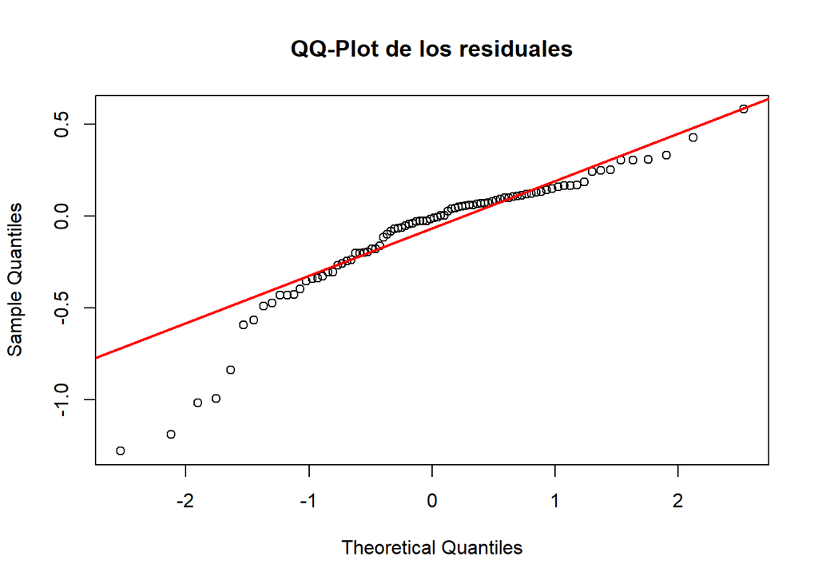

```r
qqnorm(residuals.glm(bn_final), main = "QQ-Plot de los residuales")
qqline(residuals.glm(bn_final), col = "red", lwd = 2)
```

Para confirmar la sospecha de no normalidad se decidió hacer la prueba de $Shapiro-Wilk$

```r
shapiro.test(residuals.glm(bn_final))
```

```
##
##  Shapiro-Wilk normality test
##
## data:  residuals.glm(bn_final)
## W = 0.8871, p-value = 1.411e-06
```

De este modo confirmamos que la normalidad se rechaza con un p valor menor al nivel de significancia ($\alpha=0.05$)

### *Homocedasticidad*

Para evaluar la heteroscedasticidad formalmente, tomando en cuenta que la población no sigue o proviene de una distrincuón normal, se decidió aplicar el test de Breusch-pagan.

```
##
##  studentized Breusch-Pagan test
##
## data:  bn_final
## BP = 3.7795, df = 4, p-value = 0.4367
```

#### Verificación de Sobredispersión

Si el parámetro de dispersión es mucho mayor a 1, el modelo Poisson estándar podría estar subestimando los errores estándar.

```r
check_overdispersion(bn_final)
```

```
## # Overdispersion test
##
##  dispersion ratio =   0.130
##           p-value = < 0.001
```

```
## Underdispersion detected.
```

```r
# Test simple de sobredispersión (Ratio Chi-cuadrado / Grados de libertad)
dispersion_ratio <- fit_bn$deviance / fit_bn$df.residual
cat("Ratio de dispersión:", dispersion_ratio, "\n")
```

```
## Ratio de dispersión: 0.1012141
```

```r
# Si el ratio > 1.2-1.5, considera Quasi-Poisson o Binomial Negativa
```

### Comparacion de modelos por AIC

```r
# Comparación de Criterios de Información (AIC)
# Se espera que el AIC sea significativamente menor al del Poisson final (394.06)
model_comparison <- data.frame(
  Modelo = c("Normal", "Poisson Final", "Binom. Negativa", "quasi Poisson"),
  AIC = c(AIC(mco_ajus1), AIC(poisson_final), AIC(bn_final), AIC(qpoisson_final))
)
print(model_comparison)
```

```
##            Modelo        AIC
## 1          Normal -1406.8914
## 2   Poisson Final   491.3670
## 3 Binom. Negativa   392.0116
## 4   quasi Poisson         NA
```

```r
# Si el p-valor es < 0.05, la Binomial Negativa es mejor que Poisson
p_valor_test <- 1 - pchisq(2 * (logLik(mco_ajus1) - logLik(bn_final)), df = 1)
print(paste("P-valor del test de sobredispersión:", p_valor_test))
```

```
## [1] "P-valor del test de sobredispersión: 0"
```

### 3. Comparación Visual de Predicciones

Compararemos cómo cada modelo predice la **tasa** final.

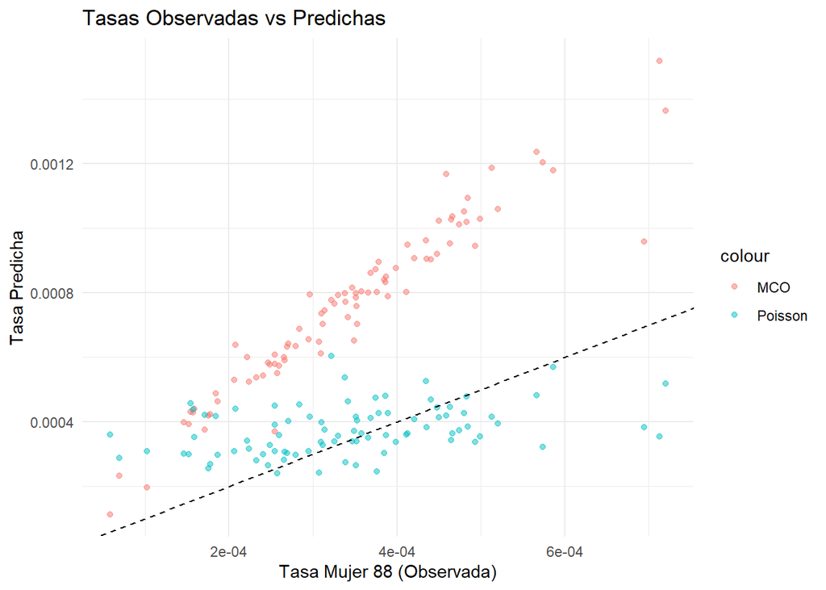

```r
# Predicciones de tasa para MCO
ohlung$pred_mco <- predict(mco_ajus1)

# Predicciones de tasa para Poisson (Exp(log_mu) / población)
ohlung$pred_poisson <- predict(poisson_final, type = "response") / ohlung$POPF88

# Gráfico de comparación: Observado vs Predicho
ggplot(ohlung, aes(x = tasa_mujer_88)) +
  geom_point(aes(y = pred_mco, color = "MCO"), alpha = 0.5) +
  geom_point(aes(y = pred_poisson, color = "Poisson"), alpha = 0.5) +
  geom_abline(intercept = 0, slope = 1, linetype = "dashed") +
  labs(title = "Tasas Observadas vs Predichas",
       x = "Tasa Mujer 88 (Observada)",
       y = "Tasa Predicha") +
  theme_minimal()
```

### 4. Autocorrelación Espacial en Residuales de Poisson

Es vital verificar si el modelo de Poisson ha capturado la estructura espacial mejor o peor que el OLS.

```r
# Cálculo de residuales de Pearson para el test de Moran
res_poisson <- residuals(mco_ajus1, type = "pearson")

# Test de Moran
moran.test(res_poisson, W_seleccionada, alternative = "two.sided", zero.policy = TRUE)
```

```
##
##  Moran I test under randomisation
##
## data:  res_poisson
## weights: W_seleccionada
##
## Moran I statistic standard deviate = 0.61069, p-value = 0.5414
## alternative hypothesis: two.sided
## sample estimates:
## Moran I statistic       Expectation          Variance
##        0.01889075       -0.01149425        0.00247561
```

```r
# Cálculo de residuales de Pearson para el test de Moran
res_poisson <- residuals(qpoisson_final, type = "pearson")

# Test de Moran
moran.test(res_poisson, W_seleccionada, alternative = "two.sided", zero.policy = TRUE)
```

```
##
##  Moran I test under randomisation
##
## data:  res_poisson
## weights: W_seleccionada
##
## Moran I statistic standard deviate = 2.3414, p-value = 0.01921
## alternative hypothesis: two.sided
## sample estimates:
## Moran I statistic       Expectation          Variance
##       0.117105881      -0.011494253       0.003016585
```

## Ajuste del Modelo Espacial: Filtrado de Eigenvectores (MESF)

```r
# 1. Identificación de filtros espaciales (eigenvectores) para el GLM Poisson
# Usamos el umbral estándar alpha = 0.1 para la selección de filtros
set.seed(5626) # Para asegurar reproducibilidad
filtros_finales1 <- ME(LF88 ~ cambio_68_78 + tasa_white_78,
                      data = ohlung,
                      offset = log(POPF88),
                      family = poisson(link = "log"),
                      listw = W_seleccionada,
                      alpha = 0.1)

filtros_finales2 <- glm(LF88  ~ cambio_68_78 + tasa_white_78      ,
                   offset = log(POPF88),
                   family = quasipoisson(link = "log"),
                   data = ohlung)


# 2. Resumen de los filtros encontrados
print(filtros_finales1)
```

```
##   Eigenvector ZI pr(ZI)
## 0          NA NA   0.02
## 1          20 NA   0.13
```

```r
print(filtros_finales2)
```

```
##
## Call:  glm(formula = LF88 ~ cambio_68_78 + tasa_white_78, family = quasipoisson(link = "log"),
##     data = ohlung, offset = log(POPF88))
##
## Coefficients:
##   (Intercept)   cambio_68_78  tasa_white_78
##        -8.659       -730.478       2055.251
##
## Degrees of Freedom: 87 Total (i.e. Null);  85 Residual
## Null Deviance:       175.3
## Residual Deviance: 115.6     AIC: NA
```

```r
# 3. Ajuste del modelo de Poisson Espacial (MESF)
# Incluimos los filtros significativos como variables explicativas adicionales
fit_poisson_mesf <- glm(LF88 ~ cambio_68_78 + tasa_white_78 + fitted(filtros_finales1),
                        family = poisson(link = "log"),
                        data = ohlung,
                        offset = log(POPF88))
fit_qpoisson_mesf <- glm(LF88 ~ cambio_68_78 + tasa_white_78 + fitted(filtros_finales2),
                        family = quasipoisson(link = "log"),
                        data = ohlung,
                        offset = log(POPF88))

summary(fit_poisson_mesf)
```

```
##
## Call:
## glm(formula = LF88 ~ cambio_68_78 + tasa_white_78 + fitted(filtros_finales1),
##     family = poisson(link = "log"), data = ohlung, offset = log(POPF88))
##
## Coefficients:
##                           Estimate Std. Error z value Pr(>|z|)
## (Intercept)                -8.7265     0.1144 -76.294  < 2e-16 ***
## cambio_68_78             -858.4260   355.7520  -2.413  0.01582 *
## tasa_white_78            2238.6207   296.3552   7.554 4.23e-14 ***
## fitted(filtros_finales1)   -0.5568     0.1710  -3.255  0.00113 **
## ---
## Signif. codes:  0 '***' 0.001 '**' 0.01 '*' 0.05 '.' 0.1 ' ' 1
##
## (Dispersion parameter for poisson family taken to be 1)
##
##     Null deviance: 175.29  on 87  degrees of freedom
## Residual deviance: 105.81  on 84  degrees of freedom
## AIC: 483.56
##
## Number of Fisher Scoring iterations: 4
```

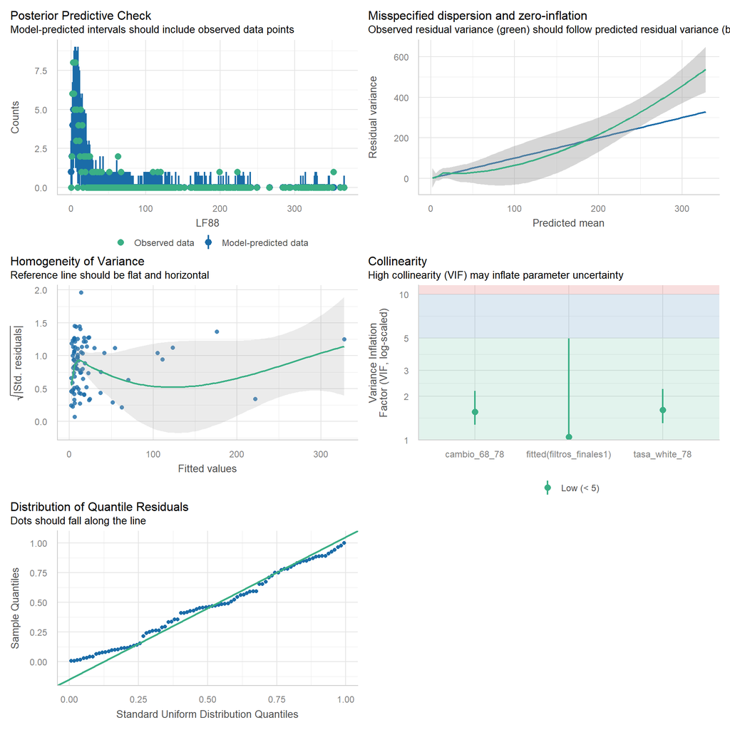

```r
check_model(fit_poisson_mesf)
```

```r
summary(fit_qpoisson_mesf)
```

```
##
## Call:
## glm(formula = LF88 ~ cambio_68_78 + tasa_white_78 + fitted(filtros_finales2),
##     family = quasipoisson(link = "log"), data = ohlung, offset = log(POPF88))
##
## Coefficients:
##                            Estimate Std. Error t value Pr(>|t|)
## (Intercept)              -8.590e+00  1.328e-01 -64.701  < 2e-16 ***
## cambio_68_78             -4.435e+02  4.375e+02  -1.014    0.314
## tasa_white_78             1.696e+03  3.863e+02   4.390 3.28e-05 ***
## fitted(filtros_finales2)  4.404e-04  2.425e-04   1.816    0.073 .
## ---
## Signif. codes:  0 '***' 0.001 '**' 0.01 '*' 0.05 '.' 0.1 ' ' 1
##
## (Dispersion parameter for quasipoisson family taken to be 1.289367)
##
##     Null deviance: 175.29  on 87  degrees of freedom
## Residual deviance: 111.37  on 84  degrees of freedom
## AIC: NA
##
## Number of Fisher Scoring iterations: 4
```

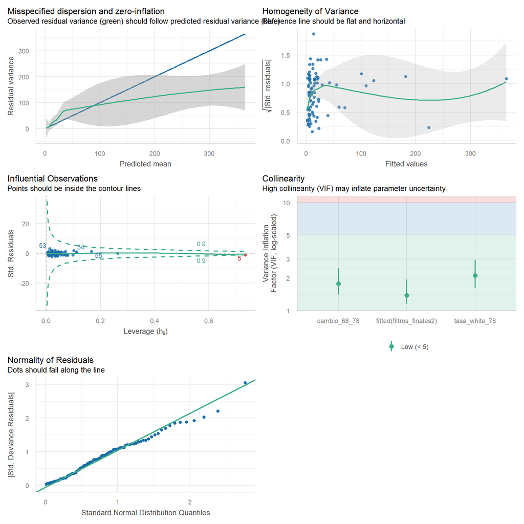

```r
check_model(fit_qpoisson_mesf)
```

### Verificación del Ajuste y Autocorrelación Residual

Procedemos a verificar si la inclusión de los componentes espaciales eliminó la dependencia en los residuos y mejoró la bondad de ajuste (AIC).

```r
# Test de Moran sobre los residuales de Pearson del modelo MESF
res_finales <- residuals(fit_poisson_mesf, type = "pearson")
moran_final <- moran.test(res_finales, W_seleccionada, zero.policy = TRUE)
print(moran_final)
```

```
##
##  Moran I test under randomisation
##
## data:  res_finales
## weights: W_seleccionada
##
## Moran I statistic standard deviate = 1.7667, p-value = 0.03864
## alternative hypothesis: greater
## sample estimates:
## Moran I statistic       Expectation          Variance
##       0.085362249      -0.011494253       0.003005488
```

```r
# Comparación de criterios de información
AIC_comparativa <- data.frame(
  Modelo = c("Poisson Aspacial (Anterior)", "Poisson MESF (Espacial)"),
  AIC = c(AIC(poisson_final), AIC(fit_poisson_mesf)),
  Moran_p_valor = c(0.0047, moran_final$p.value)
)
print(AIC_comparativa)
```

[output not shown]

```r
# Verificación de la dispersión tras el ajuste espacial
library(performance)
check_overdispersion(fit_poisson_mesf)
```

```
## # Overdispersion test
##
##        dispersion ratio =  1.183
##   Pearson's Chi-Squared = 99.360
##                 p-value =  0.121
```

```
## No overdispersion detected.
```

## Comparación de Modelos Aspaciales y Espaciales

Dado que los modelos de la familia `quasipoisson` no proporcionan un AIC estándar, implementamos una función para calcular el **QAIC** y comparamos la **Razón de Dispersión (Devianza)** y la **Autocorrelación (Moran)** entre los modelos ajustados.

```r
library(performance)
library(knitr)

# 1. Función para calcular QAIC manualmente
# Nota: Usamos el logLik del modelo Poisson base y la dispersión del Quasi
calcular_qaic <- function(modelo_quasi, modelo_poisson_base) {
  phi <- summary(modelo_quasi)$dispersion
  ll <- as.numeric(logLik(modelo_poisson_base))
  k <- length(coef(modelo_quasi))
  return(-2 * ll / phi + 2 * k)
}

# Función para calcular QBIC (análogo al BIC para modelos Quasi)
calcular_qbic <- function(modelo_quasi, modelo_poisson_base) {
  phi <- summary(modelo_quasi)$dispersion
  ll <- as.numeric(logLik(modelo_poisson_base))
  k <- length(coef(modelo_quasi))
  n <- length(residuals(modelo_quasi))
  return(-2 * ll / phi + k * log(n))
}

# 2. Extracción de Razón de Dispersión y Moran
get_diag <- function(modelo, w_mat) {
  res <- residuals(modelo, type = "pearson")
  m_test <- moran.test(res, w_mat, zero.policy = TRUE)
  ratio <- sum(res^2) / df.residual(modelo)
  return(list(ratio = ratio, moran_p = m_test$p.value))
}

# 3. Construcción de la Tabla Comparativa
modelos_nombres <- c("MCO (Normal)", "Poisson Final", "Quasi-Poisson", "Poisson MESF", "Quasi-Poisson MESF")

tab_comp <- data.frame(
  Modelo = modelos_nombres,

  # AIC / QAIC
  AIC_QAIC = c(
    AIC(mco_ajus1),
    AIC(poisson_final),
    calcular_qaic(qpoisson_final, poisson_final),
    AIC(fit_poisson_mesf),
    calcular_qaic(fit_qpoisson_mesf, fit_poisson_mesf)
  ),

  # BIC / QBIC
  BIC_QBIC = c(
    BIC(mco_ajus1),
    BIC(poisson_final),
    calcular_qbic(qpoisson_final, poisson_final),
    BIC(fit_poisson_mesf),
    calcular_qbic(fit_qpoisson_mesf, fit_poisson_mesf)
  ),

  # Log-Likelihood (Pura medida de ajuste)
  LogLik = c(
    logLik(mco_ajus1),
    logLik(poisson_final),
    NA, # Quasi-modelos no tienen LogLik real
    logLik(fit_poisson_mesf),
    NA
  ),

  Dispersion_Ratio = c(
    NA, # MCO no aplica ratio de conteo
    check_overdispersion(poisson_final)$dispersion_ratio,
    summary(qpoisson_final)$dispersion,
    check_overdispersion(fit_poisson_mesf)$dispersion_ratio,
    summary(fit_qpoisson_mesf)$dispersion
  ),

  Moran_p_value = c(
    get_diag(mco_ajus1, W_seleccionada)$moran_p,
    get_diag(poisson_final, W_seleccionada)$moran_p,
    get_diag(qpoisson_final, W_seleccionada)$moran_p,
    get_diag(fit_poisson_mesf, W_seleccionada)$moran_p,
    get_diag(fit_qpoisson_mesf, W_seleccionada)$moran_p
  )
)

knitr::kable(tab_comp, digits = 4, caption = "Comparativa de Criterios de Información y Diagnóstico Espacial")
```

Comparativa de Criterios de Información y Diagnóstico Espacial

| Modelo | AIC_QAIC | BIC_QBIC | LogLik | Dispersion_Ratio | Moran_p_value |
| --- | --- | --- | --- | --- | --- |
| MCO (Normal) | -1406.8914 | -1394.5048 | 708.4457 | NA | 0.2707 |
| Poisson Final | 491.3670 | 498.7990 | -242.6835 | 1.2839 | 0.0096 |
| Quasi-Poisson | 384.0316 | 391.4636 | NA | 1.2839 | 0.0096 |
| Poisson MESF | 483.5559 | 493.4653 | -237.7780 | 1.1829 | 0.0386 |
| Quasi-Poisson MESF | 376.8289 | 386.7382 | NA | 1.2894 | 0.0039 |

1. **QAIC:** El modelo con el valor más bajo de QAIC será el preferido en términos de equilibrio entre ajuste y parsimonia, considerando la estructura de varianza corregida.
2. **Independencia Espacial:** Si el `Moran_p_value` es > 0.05, el modelo (especialmente los MESF) ha logrado cumplir el supuesto de independencia, lo cual es el objetivo principal del filtrado de eigenvectores.
3. **Dispersión:** Para los datos de Ohio, que han mostrado subdispersión o sobredispersión moderada, el modelo que acerque el `Dispersion_Ratio` a 1 será el más confiable para la inferencia de los p-valores.
[^1]: mcamargori@unal.edu.co
[^2]: laumartinezca@unal.edu.co